# QSGA Whitepaper 5 - Testing Non-Triviality of Random Order perturbed Laplacians

**Ohad Lev**

**November-December 2025**

```python
from pathlib import Path
from typing import Iterable

import numpy as np
from numpy.typing import NDArray

from scipy import sparse
from scipy.stats import wasserstein_distance

import pandas as pd
import matplotlib.pyplot as plt
from rich.pretty import pprint

EXP_DATA_PATH = Path("/home/ohad-lev/ohad/msc/research/thesis/qsga/experiments_data_archive/")
```

In this whitepaper we examine random-order perturbed (ROP) Laplacians from various aspects to make sure these instances aren't trivial to analyze by analytical means or some lightweight approximation schemes.

The first method we already tested in this context, is comparing ROP graphs with random Erdos-Renyi weighted graphs of roughly the same (unweighted) density, and also the with similar "weighted density". To make the weighted density is similar, we have computed the average edge-weight in the ROP graph, and associated weigths for the ER graph's edges by uniformly sampling from some fixed interval around the average. For example:

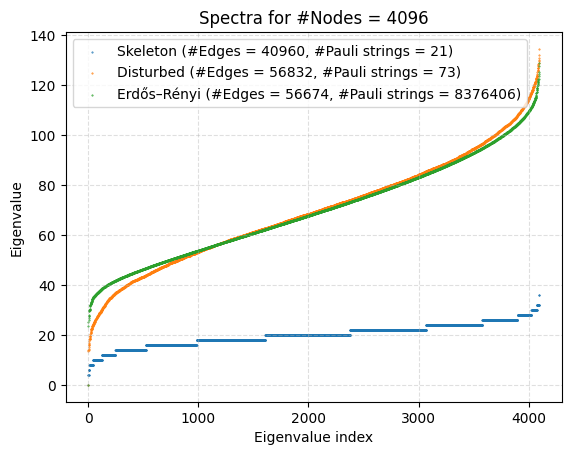

I have also added one more graph type for comparison: a random ER graph with roughly the same edge density, where weights are sampled unifromly from a distribution taken directly from the ROP graph (**red curve**):

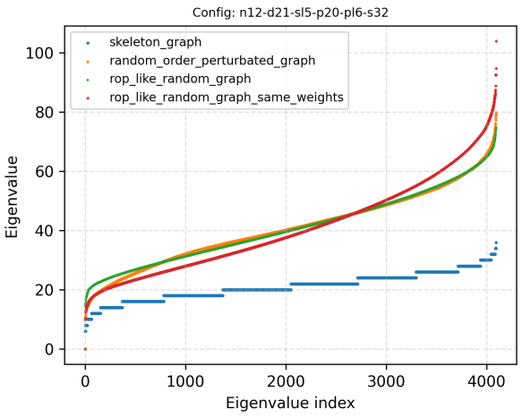

Indeed it looks good that there is a clear spectra separation between the ROP graph (**orange**) to the trivial skeleton graph (**blue**). It also looks that our ROP graph's spectrum (**orange**) looks very much similar to the spectrum of the ER graph (**green**) generated as we discussed above. The recently added **red** curve looks quite similar but slightly off compared to the ER **green** curve.

I think this evidence is nice, but not enough to claim for non-triviality of the ROP graphs. Hence in this whitepaper I am suggesting and analyzing additional methods to consolidate our conjecture that ROP graphs aren't trivial to analyze, which are:

1. Denying applicabilty of perturbation theory toolset by injecting strong enough perturbations.
2. Examining the structure of the various Laplacian matrices.
3. Analyzing the various spectra by visual and quantitative means.
4. Testing chosen graph properties of the ROP graphs compared to the others.

## (1) The Perturbation Theory Argument

In general, there exist no analytic method to diagonalize matrices of dimensions $N \times N$, where $N \ge 5$. Nevertheless, the numerical methods for diagonalization such as QR are very reliable and ubiquitous, with an efficient complexity of $O(N^3)$. By employing Krylov subspace methods such as the Lanczos algorithm, the complexity is reduced to $O(N^2)$ to obtain a part of the matrix spectrum, or even $O(|E|)$ in the sparse case. However, if $N \sim \exp(n)$, then it seems that we have no efficient method of diagonalization w.r.t $n$.

That implies that unless proved otherwise, Laplacian matrices of graphs with $|V| = 2^n$ nodes can't be diagonalized at scale. For the skeleton Laplacian, we have already shown that there is an analytical, efficient formula to obtain any of its eigenvalues. Can we be sure that this doesn't imply that also the ROP graph Laplacians can be diagonalized at scale efficiently, possibly up to some approximation?

I don't know. However, in physics it is abundant to compute approximated eigenvalues (= energy levels) of Hamiltonians by employing perturbation theory, which states that given a base Hamiltonian $H_0$, which its spectrum is easy to compute, it's possible to approximate the spectrum of a slightly perturbed Hamiltonian:

$$ H = H_0 + P $$

Where the perturbation (Hamiltonian) $P$ is "small" enough. In other words, if the perturbation is "large" enough, then we can't compute approximated eigenvalues of $H$ with perturbation theory tools, even when the spectrum of $H_0$ is completely known to us.

In our case, the ROP graph Laplacian $L_r$ is a combination of the skeleton Laplacian $L_s$ with $n_p$ perturbations:

$$ L_{r} = L_{s} + \sum_{j = 1}^{n_p} L_{\text{p-scaled}}^j = L_s + L_{\text{p-total}} $$

Thus, we need the overall perturbation Hamiltonian $L_{\text{p-total}}$ to be "large" enough to rule out perturbation theory tools. We measure the magnitude ("small"/"large") by means of its spectral norm (for Hermitian matrices the spectral norm is the largest eigenvalue of the matrix), and we define that for perturbation theory tools to apply the requirement is:

$$ ||L_{\text{p-total}}||_2 \ll \min_{i = 1}^{|V| - 1} \big( \lambda_{i + 1}(L_s) - \lambda_i(L_s) \big) $$

Hence to rule out perturbation theory, we pose the following requirement:

$$ ||L_{\text{p-total}}||_2 > ||L_s||_2 \implies \lambda_{|V|}(L_{\text{p-total}}) > \lambda_{|V|}(L_{s}) $$

Since $\lambda_{|V|}(L_{s})$ is given analytically by (plug $k = |V|$):

$$ \lambda_k(L_s) = d - \sum_{P \in S} (-1)^{k \cdot m_P} $$

We have a well-defined lower bound for the value of $\lambda_{|V|}(L_{\text{p-total}})$. In addition, consider that another lower bound on the spectral norm of a Hermitian matrix is its largest entry absolute value:

$$ \lambda_{|V|}(L_{\text{p-total}}) \ge \max_{i, j} \big| L_{\text{p-total}}^{ij} \big| $$

Thus, we have to make sure that the following holds:

$$ \max_{i, j} \big| L_{\text{p-total}}^{ij} \big| > \lambda_{|V|}(L_{s}) $$

Since:

$$ L_{\text{p-total}} = \sum_{j = 1}^{n_p} L_{\text{p-scaled}}^j $$

And since $L_{\text{p-scaled}}$ operators are just scalings of $L_p$, which defined as:

$$ L_p (r_1, r_2, w_p) = w_p \bigl( |r_1\rangle\langle r_1| - |r_1\rangle\langle r_2| - |r_2\rangle\langle r_1| + |r_2\rangle\langle r_2| \bigr) $$

All we need to define to rule out perturbation theory (with generous spares) is:

$$ w_p > \lambda_{|V|}(L_s) \quad \forall \ w_p \quad \blacksquare $$

**Conclusion in simple words: to rule out perturbation theory tools applicabilty to compute eigenvalues of $L_r$ Laplacians based on the easily-computable eigenvalues of $L_s$ Laplacians, it is (well more than) enough to define all perturbation weights (or strenghts) $w_p$ larger than the maximum eigenvalue of $L_s$, which is efficiently computable.**

## (2) Analyzing the Laplacians Structure

I guess it might be beneficial to understand and quantify the structure of the ROP Laplacians with and without respect to the skeleton Laplacians.

Hence, We now plot schems of the non-zero entries for each type of Laplacian:

- The skeleton Laplacian $L_s$.
- The ROP (Random Order perturbed) Laplacian $L_r$.
- The total perturbation Lalplacian $L_{\text{p-total}} = L_r - L_s$.

The schemes plotted below are a result of an execution of the ROP Laplacian generation protocol with the following configuration:

- Number of qubits $n = 12 \implies$ Number of nodes $|V| = 2^{12} = 4096$.
- Skeleton regularity $d = 21$.
- Skeleton Hamiltonian locality $l_s = 5$.
- Perturbation Hamiltonian locality $p_l = 9$.
- Number of perturbations $p = 2n^2 = 2\cdot12^2 = 288$.
- `seed = 32`.

```python
data_path = Path(
    EXP_DATA_PATH,
    "2025-12-09_22-29-11/0003-n12-d21-sl5-p288-pl9-s32"
)

L_s_sparse = sparse.load_npz(Path(data_path, "skeleton_graph.laplacian.npz"))
L_r_sparse = sparse.load_npz(Path(data_path, "random_order_perturbed_graph.laplacian.npz"))

L_s_dense = L_s_sparse.toarray()
L_r_dense = L_r_sparse.toarray()
L_total_perturbation = L_r_dense - L_s_dense
```

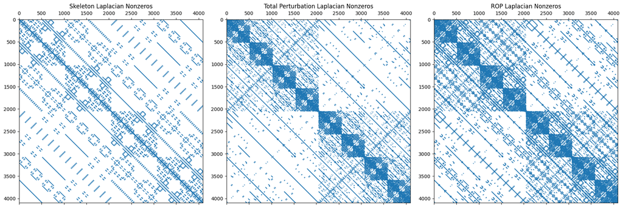

```python
markersize = 0.1
fig, axs = plt.subplots(1, 3, figsize=(18, 6))

axs[0].spy(L_s_dense, markersize=markersize)
axs[0].set_title("Skeleton Laplacian Nonzeros")

axs[1].spy(L_total_perturbation, markersize=markersize)
axs[1].set_title("Total Perturbation Laplacian Nonzeros")

axs[2].spy(L_r_dense, markersize=markersize)
axs[2].set_title("ROP Laplacian Nonzeros")

plt.tight_layout()
plt.show()
```

```python
matrix_norm_types = {
    "spectral_norm": 2,
    "frobenius_norm": "fro"
}

laplacians = {
    "skeleton_laplacian": {
        "dense_obj": L_s_dense,
    },
    "total_perturbation_laplacian": {
        "dense_obj": L_total_perturbation,
    },
    "rop_laplacian":{
        "dense_obj": L_r_dense
    }
}

for L_name in laplacians:
    L = laplacians[L_name]["dense_obj"]

    num_nonzeros = np.count_nonzero(L)
    laplacians[L_name]["num_nonzeros"] = num_nonzeros
    laplacians[L_name]["ratio_nonzeros"] = num_nonzeros / L.size

    for norm_name, norm_type in matrix_norm_types.items():
        laplacians[L_name][norm_name] = np.linalg.norm(L, norm_type)
```

```python
with np.printoptions(threshold=1, edgeitems=1):
    pprint(laplacians)
```

```
{
│   'skeleton_laplacian': {
│   │   'dense_obj': array([[21., ...,  0.],
│      ...,
│      [ 0., ..., 21.]]),
│   │   'num_nonzeros': 90112,
│   │   'ratio_nonzeros': 0.00537109375,
│   │   'spectral_norm': 36.000000000000014,
│   │   'frobenius_norm': 1375.6278566530993
│   },
│   'total_perturbation_laplacian': {
│   │   'dense_obj': array([[242.80174155, ...,   0.        ],
│      ...,
│      [  0.        , ..., 218.51170274]]),
│   │   'num_nonzeros': 222440,
│   │   'ratio_nonzeros': 0.01325845718383789,
│   │   'spectral_norm': 431.1004004647948,
│   │   'frobenius_norm': 15656.615517872593
│   },
│   'rop_laplacian': {
│   │   'dense_obj': array([[263.80174155, ...,   0.        ],
│      ...,
│      [  0.        , ..., 239.51170274]]),
│   │   'num_nonzeros': 299368,
│   │   'ratio_nonzeros': 0.01784372329711914,
│   │   'spectral_norm': 451.29453691957923,
│   │   'frobenius_norm': 16955.408014322376
│   }
}
```

```python
edges_created = (
    laplacians["rop_laplacian"]["num_nonzeros"] -
    laplacians["skeleton_laplacian"]["num_nonzeros"]
) / 2
print(f"Edges created by the perturbation process: {edges_created}")
```

```
Edges created by the perturbation process: 104628.0
```

## (3) Comparison of Graph Laplacian Spectra

As I described in the introduction of this whitepaper, it looks like there exist a significant difference in terms of spectra between skeleton graphs to ROP graphs:

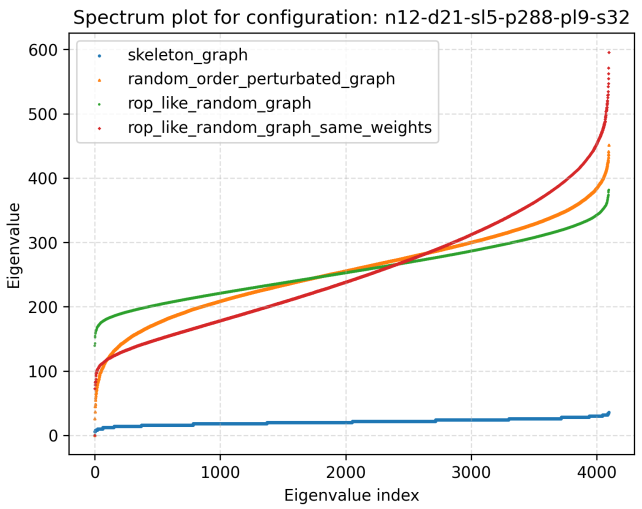

In addition, it looks like thee ROP graph's Laplacian spectrum behaves similarly to two random weighted ER variants (described in the introduction). The plot above is for the configuration detailed in Section (2).

However, can we quantify the visible difference rather than just estimating it by eye? Let's examine the following:

1. Computing the Wassertein distance between different spectra.
2. Computing the algebraic connectivity $\lambda_2$ for each Laplacian.
3. Examining the lower part of the spectra which we should care about the most, in my opinion.
4. Comparing spectra of normalized Laplacians to get intuition regarding pure graph structure change (eliminating weights).

We obtain the spectra data:

```python
graph_types = (
    "skeleton_graph",
    "random_order_perturbed_graph",
    "rop_like_random_graph",
    "rop_like_random_graph_same_weights"
)

spectra = pd.read_csv(Path(data_path, "spectra.csv"))
spectra
```

|  | k | skeleton_graph | definite_order_perturbed_graph | random_order_perturbed_graph | dop_like_random_graph | rop_like_random_graph | rop_like_random_graph_same_weights |
| --- | --- | --- | --- | --- | --- | --- | --- |
| 0 | 0 | -2.486900e-14 | 1.847411e-13 | 3.410605e-13 | -6.821210e-13 | -1.421085e-13 | 5.138219e-12 |
| 1 | 1 | 6.000000e+00 | 8.795425e+00 | 2.594394e+01 | 1.533970e+02 | 1.390310e+02 | 7.241786e+01 |
| 2 | 2 | 6.000000e+00 | 1.000000e+01 | 3.660224e+01 | 1.589815e+02 | 1.427711e+02 | 7.837030e+01 |
| 3 | 3 | 6.000000e+00 | 1.200000e+01 | 4.469739e+01 | 1.609343e+02 | 1.521387e+02 | 7.845342e+01 |
| 4 | 4 | 6.000000e+00 | 1.316482e+01 | 4.520543e+01 | 1.657700e+02 | 1.543314e+02 | 8.178096e+01 |
| ... | ... | ... | ... | ... | ... | ... | ... |
| 4091 | 4091 | 3.400000e+01 | 5.303043e+02 | 4.324516e+02 | 4.692604e+02 | 3.726739e+02 | 5.469823e+02 |
| 4092 | 4092 | 3.400000e+01 | 5.304024e+02 | 4.365380e+02 | 4.697323e+02 | 3.741319e+02 | 5.544750e+02 |
| 4093 | 4093 | 3.400000e+01 | 5.312803e+02 | 4.370348e+02 | 4.733456e+02 | 3.781418e+02 | 5.622668e+02 |
| 4094 | 4094 | 3.400000e+01 | 5.318297e+02 | 4.412188e+02 | 4.872229e+02 | 3.805239e+02 | 5.715075e+02 |
| 4095 | 4095 | 3.600000e+01 | 5.321947e+02 | 4.512945e+02 | 5.029888e+02 | 3.813121e+02 | 5.956212e+02 |

4096 rows × 7 columns

Wasserstein distance is easily computable:

```python
def compute_multi_wasserstein_distance(
    graph_types: Iterable[str],
    spectra: pd.DataFrame,
) -> pd.DataFrame:
    df = pd.DataFrame(index=graph_types, columns=graph_types, dtype=float)

    for g1 in graph_types:
        for g2 in graph_types:
            df.loc[g1, g2] = wasserstein_distance(spectra[g1], spectra[g2])

    return df


compute_multi_wasserstein_distance(graph_types, spectra).style.background_gradient(cmap="Greens")

# df_upper = df.copy()
# df_upper.values[np.tril_indices_from(df_upper, k=-1)] = np.nan
# df_upper.style.background_gradient(cmap="Greens")
```

|  | skeleton_graph | random_order_perturbed_graph | rop_like_random_graph | rop_like_random_graph_same_weights |
| --- | --- | --- | --- | --- |
| skeleton_graph | 0.000000 | 235.086464 | 235.301496 | 233.499846 |
| random_order_perturbed_graph | 235.086464 | 0.000000 | 18.114493 | 24.292270 |
| rop_like_random_graph | 235.301496 | 18.114493 | 0.000000 | 40.177293 |
| rop_like_random_graph_same_weights | 233.499846 | 24.292270 | 40.177293 | 0.000000 |

We also focus on the lower part of the spectra anc computing the algebraic connectivity:

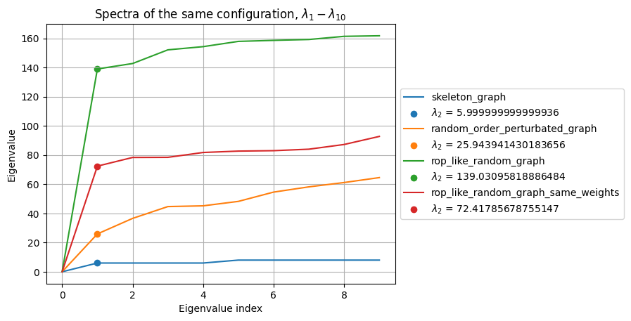

```python
start, end = 0, 10
x = range(start, end)

for graph_type in graph_types:
    plt.plot(x, spectra[graph_type][start:end], label=graph_type)

    algebraic_connectivity = spectra[graph_type][1]
    plt.scatter([1], spectra[graph_type][1], label=f"$\\lambda_2$ = {algebraic_connectivity}")

plt.legend(
    loc="center left",
    bbox_to_anchor=(1.0, 0.5)
)
plt.grid()
plt.xlabel("Eigenvalue index")
plt.ylabel("Eigenvalue")
plt.title(
    "Spectra of the same configuration, $\\lambda_{" + str(start + 1) + "} - \\lambda_{" + str(end) + "}$"
)
plt.show()
```

It can be seen that the algebraic connectivities $\lambda_2$ are significantly different.

We now take a look at the spectra of the normalized Laplacians:

```python
import numpy as np
import scipy.sparse as sp

def get_normalized_laplacian_spectrum(L):
    """
    *** VIBE-CODED WITH GEMINI, TODO NEED TO CHECK***
    Computes the spectrum of the Normalized Laplacian given a standard Laplacian L.
    L_norm = D^-1/2 * L * D^-1/2
    """

    # 1. Extract degrees from the diagonal of L
    degrees = L.diagonal()

    # 2. Compute inverse square root of degrees (D^-1/2)
    # Use errstate to ignore division by zero for isolated nodes (degree=0)
    with np.errstate(divide='ignore'):
        d_inv_sqrt = 1.0 / np.sqrt(degrees)

    # Replace infinity with 0 (for isolated nodes)
    d_inv_sqrt[np.isinf(d_inv_sqrt)] = 0

    # 3. Compute Normalized Laplacian: L_norm = D^-1/2 @ L @ D^-1/2
    if sp.issparse(L):
        # Sparse Matrix implementation
        D_op = sp.diags(d_inv_sqrt)
        L_norm = D_op @ L @ D_op
        # Convert to dense to get ALL eigenvalues (eigvalsh is fast for 4k x 4k)
        # If matrix is huge (>20k), you might want sp.linalg.eigsh for k-largest/smallest
        L_dense = L_norm.toarray()
    else:
        # Dense Array implementation (using broadcasting for speed)
        # L_ij becomes L_ij / (sqrt(d_i) * sqrt(d_j))
        L_dense = L * d_inv_sqrt[:, np.newaxis] * d_inv_sqrt[np.newaxis, :]

    # 4. Compute and sort eigenvalues
    eigvals = np.linalg.eigvalsh(L_dense)
    return np.sort(eigvals)
```

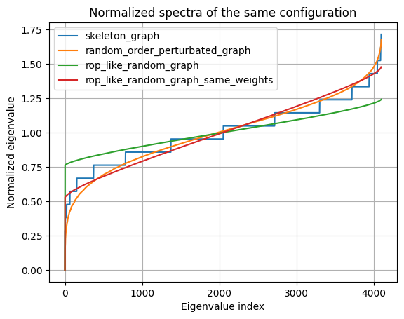

```python
normalized_spectra = dict()

for graph_type in graph_types:
    L = sparse.load_npz(Path(data_path, f"{graph_type}.laplacian.npz"))
    normalized_spectrum = get_normalized_laplacian_spectrum(L.toarray())
    normalized_spectra[graph_type] = normalized_spectrum

    plt.plot(range(2**12), normalized_spectrum, label=graph_type)

plt.grid()
plt.xlabel("Eigenvalue index")
plt.ylabel("Normalized eigenvalue")
plt.title("Normalized spectra of the same configuration")
plt.legend()

plt.show()
```

And the lower part of the normalized spectra:

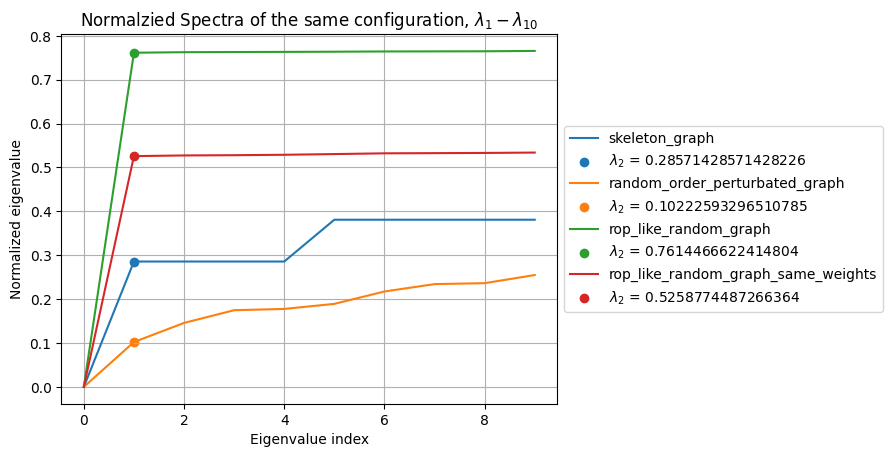

```python
start, end = 0, 10
x = range(start, end)

for graph_type in graph_types:
    plt.plot(x, normalized_spectra[graph_type][start:end], label=graph_type)

    algebraic_connectivity = normalized_spectra[graph_type][1]
    plt.scatter([1], algebraic_connectivity, label=f"$\\lambda_2$ = {algebraic_connectivity}")

plt.legend(
    loc="center left",
    bbox_to_anchor=(1.0, 0.5)
)
plt.grid()
plt.xlabel("Eigenvalue index")
plt.ylabel("Normalized eigenvalue")
plt.title(
    "Normalzied Spectra of the same configuration, $\\lambda_{"
    + str(start + 1) + "} - \\lambda_{" + str(end) + "}$"
)
plt.show()
```

It looks like the order of the different $\lambda_2$ has flipped. Not sure why.

Wasserstein distances of normalized spectra:

```python
compute_multi_wasserstein_distance(graph_types, normalized_spectra).style.background_gradient(cmap="Greens")
```

|  | skeleton_graph | random_order_perturbed_graph | rop_like_random_graph | rop_like_random_graph_same_weights |
| --- | --- | --- | --- | --- |
| skeleton_graph | 0.000000 | 0.039923 | 0.074620 | 0.046996 |
| random_order_perturbed_graph | 0.039923 | 0.000000 | 0.103214 | 0.026283 |
| rop_like_random_graph | 0.074620 | 0.103214 | 0.000000 | 0.108330 |
| rop_like_random_graph_same_weights | 0.046996 | 0.026283 | 0.108330 | 0.000000 |

## (4) Testing Graph properties

**TODO FOR NOW IT IS DUMB AND GEMINI-IMPLEMENTED**

```python
import networkx as nx
import numpy as np
import scipy.sparse as sp


def analyze_graph_properties(laplacian_matrix, sample_size=100):
    """
    Computes graph metrics for both weighted and unweighted Laplacians.
    Uses sampling for expensive metrics to handle dense graphs (ROP) efficiently.
    """
    # 1. Recover Adjacency A from Laplacian L (A_ij = -L_ij for i!=j)
    if sp.issparse(laplacian_matrix):
        A = -laplacian_matrix.copy()
        A.setdiag(0)
        A = A.abs() # Ensure positive weights
        G = nx.from_scipy_sparse_array(A)
    else:
        A = -np.array(laplacian_matrix, copy=True)
        np.fill_diagonal(A, 0)
        A = np.abs(A)
        G = nx.from_numpy_array(A)

    # 2. Check if effectively weighted (variability in weights)
    # If all weights are 1.0 (or identical), we can treat as unweighted for speed/clarity
    weights = [d['weight'] for u, v, d in G.edges(data=True)]
    is_weighted = np.var(weights) > 1e-9 if weights else False

    weight_key = 'weight' if is_weighted else None

    print(f"Graph: {G.number_of_nodes()} nodes, {G.number_of_edges()} edges. Weighted: {is_weighted}")

    # 3. Clustering Coefficient
    # Fast enough for both cases
    C = nx.average_clustering(G, weight=weight_key)

    # 4. Average Shortest Path Length (approximated)
    # Full calculation is O(V*E), too slow for your dense ROP graph. We sample.
    nodes = list(G.nodes())
    sampled_sources = np.random.choice(nodes, min(sample_size, len(nodes)), replace=False)

    path_lengths = []
    for source in sampled_sources:
        # standard Dijkstra minimizes SUM of weights (or hops if unweighted)
        lengths = nx.single_source_dijkstra_path_length(G, source, weight=weight_key)
        path_lengths.extend(lengths.values())

    L_avg = np.mean(path_lengths) if path_lengths else 0.0

    # 5. Betweenness Centrality (approximated)
    # k=sample_size significantly speeds this up for dense graphs
    centrality_dict = nx.betweenness_centrality(G, k=sample_size, weight=weight_key)
    centrality_vals = list(centrality_dict.values())

    # 6. Modularity
    # Louvain is standard. Handles weights automatically if present.
    try:
        communities = nx.community.louvain_communities(G, weight=weight_key, seed=42)
        Q = nx.community.modularity(G, communities, weight=weight_key)
    except Exception:
        Q = 0.0

    return {
        "is_weighted": is_weighted,
        "clustering_coefficient": C,
        "avg_path_length_est": L_avg,
        "max_betweenness_est": np.max(centrality_vals) if centrality_vals else 0,
        "modularity": Q
    }
```

```python
metrics_skel = analyze_graph_properties(L_s_dense)
metrics_rop = analyze_graph_properties(L_r_dense)
```

```python
print("Skeleton:")
pprint(metrics_skel)

print("ROP:")
pprint(metrics_rop)
```

```
Skeleton:
```

```
{
│   'is_weighted': False,
│   'clustering_coefficient': 0.014285714285714285,
│   'avg_path_length_est': 3.772705078125,
│   'max_betweenness_est': 0.002406036224129776,
│   'modularity': 0.47123645600818453
}
```

```
ROP:
```

```
{
│   'is_weighted': True,
│   'clustering_coefficient': 0.0034734352271310665,
│   'avg_path_length_est': 2.79983945506183e-17,
│   'max_betweenness_est': 0.017778786103319268,
│   'modularity': 0.6548472391734901
}
```

# DRAFTS

## Weyl's Inequality Bound

By Weyl's inequality:

$$ \max_i|\lambda_i(A) - \lambda_i(B)| \le || A - B ||_s $$

Meaning, the largest absolute difference between a pair of ordered eigenvalues is bounded from above by the spectral norm of the matrices difference. Here:

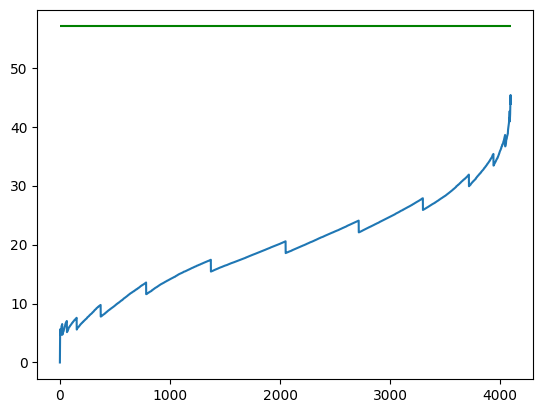

```python
import matplotlib.pyplot as plt

plt.plot(
    spectra_data["k"],
    np.abs(spectra_data["random_order_perturbed_graph"] - spectra_data["skeleton_graph"])
)

plt.hlines(y=spectral_norm_diff, xmin=0, xmax=2**12, color="green")
plt.show()
```

## Commutator and Frobenius Norm

```python
from scipy.linalg import norm

comm = rop_laplacian @ skeleton_laplacian - skeleton_laplacian @ rop_laplacian
fro_norm = norm(comm, "fro")

fro_norm
```

```
2840.87778562782
```

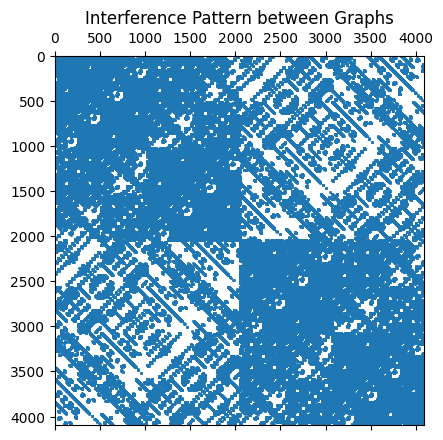

```python
plt.spy(comm, markersize=1)
plt.title("Interference Pattern between Graphs")
```

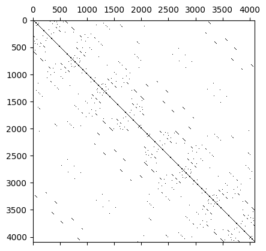

```python
plt.spy(skeleton_laplacian)
```

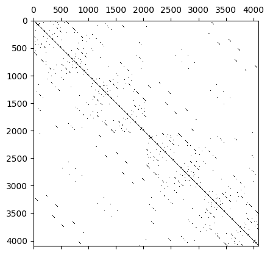

```python
plt.spy(rop_laplacian)
```

## Graph Properties

```python
import networkx as nx


skeleton_graph_json_path = Path(config_data_path, "skeleton_graph.graph.json")
disturbed_graph_json_path = Path(config_data_path, "random_order_perturbed_graph.graph.json")
er_graph_json_path = Path(config_data_path, "rop_like_random_graph.graph.json")

with open(skeleton_graph_json_path) as f:
    skeleton_graph_data = json.load(f)

with open(disturbed_graph_json_path) as f:
    disturbed_graph_data = json.load(f)

with open(er_graph_json_path) as f:
    er_graph_data = json.load(f)

skeleton_graph = nx.node_link_graph(skeleton_graph_data)
disturbed_graph = nx.node_link_graph(disturbed_graph_data)
er_graph = nx.node_link_graph(er_graph_data)
```

```python
nx.average_clustering(skeleton_graph, weight='weight')
```

```
0.04736842105263158
```

```python
nx.average_clustering(er_graph, weight='weight')
```

```
0.0043479739842365835
```

```python
nx.average_clustering(disturbed_graph, weight='weight')
```

```
0.0035277795241439864
```

```python
import numpy as np
import matplotlib.pyplot as plt

eigenvalues_skeleton = spectra.skeleton_graph
eigenvalues_disturbed = spectra.random_order_perturbed_graph
eigenvalues_er = spectra.rop_like_random_graph
```

[output not shown]

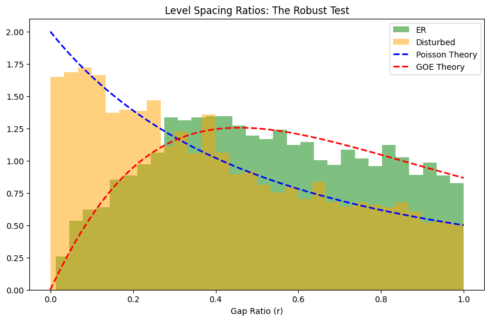

```python
import numpy as np
import matplotlib.pyplot as plt

def get_gap_ratios(eigenvalues, tolerance=1e-10):
    # 1. Sort
    eigs = np.sort(eigenvalues)

    # 2. Remove degeneracies (crucial for Skeleton graphs!)
    # We only keep unique eigenvalues to calculate level statistics
    unique_eigs = eigs[np.diff(np.insert(eigs, 0, -np.inf)) > tolerance]

    # 3. Calculate gaps
    gaps = np.diff(unique_eigs)

    # 4. Calculate ratios of consecutive gaps
    # r_n = min(g_n, g_{n+1}) / max(g_n, g_{n+1})
    numerators = np.minimum(gaps[:-1], gaps[1:])
    denominators = np.maximum(gaps[:-1], gaps[1:])

    # Avoid division by zero (just in case)
    valid_indices = denominators > tolerance
    ratios = numerators[valid_indices] / denominators[valid_indices]

    return ratios

# Calculate Ratios
r_skel = get_gap_ratios(eigenvalues_skeleton)
r_dist = get_gap_ratios(eigenvalues_disturbed)
r_er   = get_gap_ratios(eigenvalues_er)

# --- THE VERDICT ---
print(f"Skeleton Mean r:  {np.mean(r_skel):.4f} (Target: ~0.39)")
print(f"Disturbed Mean r: {np.mean(r_dist):.4f} (Target: ~0.54)")
print(f"ER Graph Mean r:  {np.mean(r_er):.4f}   (Target: ~0.54)")

# --- PLOT DISTRIBUTION OF R ---
# P(r) for Poisson = 2 / (1+r)^2
# P(r) for GOE is approx (27/4) * (r + r^2) / (1 + r + r^2)^2.5
r_vals = np.linspace(0, 1, 100)
p_poisson = 2 / (1 + r_vals)**2
p_goe = (27/4) * (r_vals + r_vals**2) / (1 + r_vals + r_vals**2)**2.5

plt.figure(figsize=(10, 6))
# plt.hist(r_skel, bins=30, density=True, alpha=0.5, label='Skeleton', color='blue')
plt.hist(r_er, bins=30, density=True, alpha=0.5, label='ER', color='green')
plt.hist(r_dist, bins=30, density=True, alpha=0.5, label='Disturbed', color='orange')
plt.plot(r_vals, p_poisson, 'b--', label='Poisson Theory', linewidth=2)
plt.plot(r_vals, p_goe, 'r--', label='GOE Theory', linewidth=2)

plt.xlabel('Gap Ratio (r)')
plt.title('Level Spacing Ratios: The Robust Test')
plt.legend()
plt.show()
```

```python
eigenvalues_skeleton[1]
```

[output not shown]

```python
eigenvalues_disturbed[1]
```

[output not shown]

```python
eigenvalues_er[1]
```

[output not shown]

```python
import numpy as np

L_p = np.load(Path(config_data_path, "random_order_perturbed_graph.laplacian.npy"))
L_er = np.load(Path(config_data_path, "rop_like_random_graph.laplacian.npy"))
```

[output not shown]

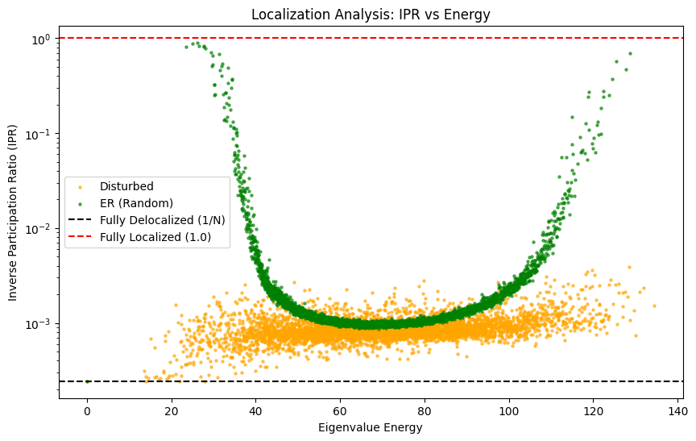

```python
import numpy as np
import matplotlib.pyplot as plt

def calculate_ipr(eigenvectors):
    """
    eigenvectors: A matrix where columns are the eigenvectors.
                  Shape should be (N_nodes, N_modes)
    """
    # Ensure we are taking the element-wise modulus and raising to power 4
    # Axis=0 sums down the column (i.e., sums over the nodes for a specific eigenvector)
    iprs = np.sum(np.abs(eigenvectors)**4, axis=0)
    return iprs

# --- HOW TO USE WITH YOUR DATA ---

# 1. Get Eigenvalues and Eigenvectors
# precise_diagonalization is assumed from your previous steps (e.g., np.linalg.eigh)
evals_dist, evecs_dist = np.linalg.eigh(L_p)
evals_er, evecs_er     = np.linalg.eigh(L_er)

# 2. Calculate IPRs
ipr_dist = calculate_ipr(evecs_dist)
ipr_er   = calculate_ipr(evecs_er)

# 3. Analyze the Fiedler Vector (Index 1, since Index 0 is the trivial ground state)
N = evecs_dist.shape[0]
fiedler_ipr_dist = ipr_dist[1]
fiedler_ipr_er = ipr_er[1]

print(f"Number of Nodes (N): {N}")
print(f"Theoretical Delocalized Limit (1/N): {1/N:.6f}")
print("-" * 30)
print(f"Disturbed Fiedler IPR: {fiedler_ipr_dist:.6f}")
print(f"ER Graph Fiedler IPR:  {fiedler_ipr_er:.6f}")

# --- 4. PLOT: The "Mobility Edge" ---
# This shows if *some* energy levels are localized while others are chaotic
plt.figure(figsize=(10, 6))
plt.scatter(evals_dist, ipr_dist, s=5, label='Disturbed', alpha=0.6, color='orange')
plt.scatter(evals_er, ipr_er, s=5, label='ER (Random)', alpha=0.6, color='green')

# Log scale is often better for IPR
plt.yscale('log')
plt.xlabel('Eigenvalue Energy')
plt.ylabel('Inverse Participation Ratio (IPR)')
plt.title('Localization Analysis: IPR vs Energy')
plt.axhline(y=1/N, color='k', linestyle='--', label='Fully Delocalized (1/N)')
plt.axhline(y=1.0, color='r', linestyle='--', label='Fully Localized (1.0)')
plt.legend()
plt.show()
```